# Table of Content:

1. **Introduction**
2. **Notebook Structure**
3. **Gathering**
4. **Assessing**
5. **Cleaning**
6. **Data Storing**

# Introduction

This project has **two notebooks** that needed to perform the compelete data analysis process.

In the **first notebook**, we will start with [**Data Wrangling**](https://en.wikipedia.org/wiki/Data_wrangling) techniques, e.g. **Gather**, **Assess** and **Clean** **The Dataset**.

While, in the **second notebook**, we will use Python visualization libraries to systematically `explore` a selected dataset, starting from plots of single variables and building up to plots of multiple variables, then `communicate` the interesting properties, trends, and relationships that we discovered through aesthetic and polished visuals.

**Before anything, let's find out:**

- **The Dataset**
- **Coronavirus Pandemic**
- **Variables Description**
- **Our Goal**
- **Project Outline**

Back to Top

## The Dataset

**The data** I will be using (and analyzing and visualizing) is dataset about **Coronavirus** Pandemic (COVID-19) avalibale via [**Our World in Data**](https://ourworldindata.org/coronavirus) website.

According to [WikiPedia](https://en.wikipedia.org/wiki/Our_World_in_Data), **Our World in Data** (OWID) is a scientific online publication that focuses on large global problems such as poverty, disease, hunger, climate change, war, existential risks, and inequality.

The trajectories show the daily number of confirmed cases. But the widely available data on confirmed cases only becomes meaningful when it can be interpreted in light of how much a country is testing. This is why **Our World in Data** built the [global database on COVID-19 testing](https://ourworldindata.org/coronavirus-testing) and the line colors in this chart show whether a country is testing adequately or not.

**Note:** This project is dated `21-9-2020`.

Back to Introduction

## Coronavirus Pandemic

The [**Coronavirus**](https://www.undp.org/content/undp/en/home/coronavirus.html) COVID-19 pandemic is the defining global health crisis of our time and the greatest challenge we have faced since World War Two. Since its emergence in Asia late last year, the virus has spread to every continent except Antarctica.

But the **pandemic** is much more than a `health crisis`, it's also an unprecedented `socio-economic crisis`. Stressing every one of the countries it touches, it has the potential to create devastating social, economic and political effects that will leave deep and longstanding scars. UNDP is the technical lead in the UN’s socio-economic recovery, alongside the health response, led by WHO, and the Global Humanitarian Response Plan, and working under the leadership of the UN Resident Coordinators.

In this **project**, I'm will try to find some `insights` or `answers` that may help people or reduce suffering due to this pandemic.

Back to Introduction

## Variables Description

This [**link**](https://github.com/owid/covid-19-data/blob/master/public/data/owid-covid-codebook.csv) on Github provided by [**Our World in Data**](https://ourworldindata.org/coronavirus) website, contains all the descriptions of the variables that we will be using.

Back to Introduction

## Our Goal

Data visualization is an important skill that is used in many parts of the data analysis process.

**Our goals will be:**

- Performing both **exploratory** data visualization and **explanatory** data visualization.
- Supplement **statistics** with **visualizations** to build understanding of data.
- Choose appropriate **plots**, **limits**, **transformations**, and **aesthetics** to explore the dataset.
- Use **design principles** to create effective visualizations for communicating findings to an audience.

Back to Introduction

## Project Outline

In this **project** I'm going to perform all of the sections below:

- [ ] Gathering
- [ ] Assessing
- [ ] Cleaning
- [ ] Storing
- [ ] Analyzing
- [ ] Visualizing
- [ ] Reporting

Back to Introduction

# Notebook Structure

**This Notebook will be structured as follows:**

- We will start with **Data Wrangling Process** to Gather, Assess and Clean the data.
- After wrangling our data, we will storing it for any future purposes.

Back to Top

# Gathering Data

Data wrangling consists of three steps: **Gathering**, **Assessing** and **Cleaning**

[Gathering data](https://ori.hhs.gov/education/products/n_illinois_u/datamanagement/dctopic.html) is the first step in data wrangling. It is the process of collecting and measuring information on variables of interest, in an established systematic fashion that enables one to answer stated research questions, test hypotheses, and evaluate outcomes.

For this project, data are ready and available to be downloaded. So, no further effort need for this step.

Back to Top

```python
# importing necessary libraries
import pandas as pd
import seaborn as sb
import matplotlib.pyplot as plt
import numpy as np
import geopandas as gpd
from matplotlib.lines import Line2D
from mpl_toolkits.axes_grid1 import make_axes_locatable
import matplotlib.cm as cm

# Setting the dark grid style
sb.set(style="darkgrid")

# Setting DPI and default figure size
plt.rcParams['figure.dpi']= 100
plt.rcParams["figure.figsize"] = [10, 4]

# importing the dataset
df = pd.read_csv('./data/owid-covid-data.csv')

print(df.shape)
display(df.head())
```

```
(45207, 41)
```

|  | iso_code | continent | location | date | total_cases | new_cases | new_cases_smoothed | total_deaths | new_deaths | new_deaths_smoothed | ... | gdp_per_capita | extreme_poverty | cardiovasc_death_rate | diabetes_prevalence | female_smokers | male_smokers | handwashing_facilities | hospital_beds_per_thousand | life_expectancy | human_development_index |
| --- | --- | --- | --- | --- | --- | --- | --- | --- | --- | --- | --- | --- | --- | --- | --- | --- | --- | --- | --- | --- | --- |
| 0 | ABW | North America | Aruba | 2020-03-13 | 2.0 | 2.0 | NaN | 0.0 | 0.0 | NaN | ... | 35973.781 | NaN | NaN | 11.62 | NaN | NaN | NaN | NaN | 76.29 | NaN |
| 1 | ABW | North America | Aruba | 2020-03-19 | NaN | NaN | 0.286 | NaN | NaN | 0.0 | ... | 35973.781 | NaN | NaN | 11.62 | NaN | NaN | NaN | NaN | 76.29 | NaN |
| 2 | ABW | North America | Aruba | 2020-03-20 | 4.0 | 2.0 | 0.286 | 0.0 | 0.0 | 0.0 | ... | 35973.781 | NaN | NaN | 11.62 | NaN | NaN | NaN | NaN | 76.29 | NaN |
| 3 | ABW | North America | Aruba | 2020-03-21 | NaN | NaN | 0.286 | NaN | NaN | 0.0 | ... | 35973.781 | NaN | NaN | 11.62 | NaN | NaN | NaN | NaN | 76.29 | NaN |
| 4 | ABW | North America | Aruba | 2020-03-22 | NaN | NaN | 0.286 | NaN | NaN | 0.0 | ... | 35973.781 | NaN | NaN | 11.62 | NaN | NaN | NaN | NaN | 76.29 | NaN |

5 rows × 41 columns

### So Far, So Good

> Now we have `gathered` **manually** all the data we needed to reach **Our Goal**. So, let's proceed to **Assessing Data** phase.
> - [x] Gathering
> - [ ] Assessing
> - [ ] Cleaning
> - [ ] Storing
> - [ ] Analyzing
> - [ ] Visualizing
> - [ ] Reporting

> Back to Gathering Data

# Assessing Data

Then let's start Assessing our data. We are going to inspect our dataset for two things, **Data Quality Issues** (i.e. content issues) and **Lack of Tidiness** (i.e. structural issues), through two steps: **detecting** and **documentation**, by using two types of assessments:

1. **Visual Assessment**
2. **Programmatic Assessment**

And finally, we will document the existing issues in **Assessment Docummentions**.

Back to Top

## Visual Assessment

Let's `detect` some quality or tideness issues in our dataset **visually**. Then `document` it in **Assessment Docummentions**

Back to Assessing Data

```python
# Assessing 'df' visually.
df
```

|  | iso_code | continent | location | date | total_cases | new_cases | new_cases_smoothed | total_deaths | new_deaths | new_deaths_smoothed | ... | gdp_per_capita | extreme_poverty | cardiovasc_death_rate | diabetes_prevalence | female_smokers | male_smokers | handwashing_facilities | hospital_beds_per_thousand | life_expectancy | human_development_index |
| --- | --- | --- | --- | --- | --- | --- | --- | --- | --- | --- | --- | --- | --- | --- | --- | --- | --- | --- | --- | --- | --- |
| 0 | ABW | North America | Aruba | 2020-03-13 | 2.0 | 2.0 | NaN | 0.0 | 0.0 | NaN | ... | 35973.781 | NaN | NaN | 11.62 | NaN | NaN | NaN | NaN | 76.29 | NaN |
| 1 | ABW | North America | Aruba | 2020-03-19 | NaN | NaN | 0.286 | NaN | NaN | 0.0 | ... | 35973.781 | NaN | NaN | 11.62 | NaN | NaN | NaN | NaN | 76.29 | NaN |
| 2 | ABW | North America | Aruba | 2020-03-20 | 4.0 | 2.0 | 0.286 | 0.0 | 0.0 | 0.0 | ... | 35973.781 | NaN | NaN | 11.62 | NaN | NaN | NaN | NaN | 76.29 | NaN |
| 3 | ABW | North America | Aruba | 2020-03-21 | NaN | NaN | 0.286 | NaN | NaN | 0.0 | ... | 35973.781 | NaN | NaN | 11.62 | NaN | NaN | NaN | NaN | 76.29 | NaN |
| 4 | ABW | North America | Aruba | 2020-03-22 | NaN | NaN | 0.286 | NaN | NaN | 0.0 | ... | 35973.781 | NaN | NaN | 11.62 | NaN | NaN | NaN | NaN | 76.29 | NaN |
| ... | ... | ... | ... | ... | ... | ... | ... | ... | ... | ... | ... | ... | ... | ... | ... | ... | ... | ... | ... | ... | ... |
| 45202 | NaN | NaN | International | 2020-09-17 | 696.0 | NaN | NaN | 7.0 | NaN | NaN | ... | NaN | NaN | NaN | NaN | NaN | NaN | NaN | NaN | NaN | NaN |
| 45203 | NaN | NaN | International | 2020-09-18 | 696.0 | NaN | NaN | 7.0 | NaN | NaN | ... | NaN | NaN | NaN | NaN | NaN | NaN | NaN | NaN | NaN | NaN |
| 45204 | NaN | NaN | International | 2020-09-19 | 696.0 | NaN | NaN | 7.0 | NaN | NaN | ... | NaN | NaN | NaN | NaN | NaN | NaN | NaN | NaN | NaN | NaN |
| 45205 | NaN | NaN | International | 2020-09-20 | 696.0 | NaN | NaN | 7.0 | NaN | NaN | ... | NaN | NaN | NaN | NaN | NaN | NaN | NaN | NaN | NaN | NaN |
| 45206 | NaN | NaN | International | 2020-09-21 | 696.0 | NaN | NaN | 7.0 | NaN | NaN | ... | NaN | NaN | NaN | NaN | NaN | NaN | NaN | NaN | NaN | NaN |

45207 rows × 41 columns

> **Note:** There are a lot of `NaN` values, but I think this normal due to the nature of the data.

# Programmatic Assessment

**Programmatic assessment** is simply means using code to do anything other than looking to the dataset in its **`entirety`**. It tends to be more efficient than visual assessment.

This types of assessments are handy for gauging data’s structure and also for quickly spotting things that we’ll need to clean.

**Note:** As We did in Visually Assessment, we'll start with `detecting` data issues, then, `documenting` these issues in Assessment Docummentions.

We are going to use [Pandas API](https://pandas.pydata.org/docs/reference/index.html) functions and methods in order to programmatically assess the datasets, e.g. sample, value_counts, info, dtypes, describe, Series.isnull and notnull

Back to Assessing Data

## Dataset Random Sample

Back to Programmatic Assessment

```python
np.random.seed(1)
df.sample(5)
```

|  | iso_code | continent | location | date | total_cases | new_cases | new_cases_smoothed | total_deaths | new_deaths | new_deaths_smoothed | ... | gdp_per_capita | extreme_poverty | cardiovasc_death_rate | diabetes_prevalence | female_smokers | male_smokers | handwashing_facilities | hospital_beds_per_thousand | life_expectancy | human_development_index |
| --- | --- | --- | --- | --- | --- | --- | --- | --- | --- | --- | --- | --- | --- | --- | --- | --- | --- | --- | --- | --- | --- |
| 43026 | VEN | South America | Venezuela | 2020-07-19 | 11483.0 | 292.0 | 329.286 | 110.0 | 3.0 | 3.571 | ... | 16745.022 | NaN | 204.850 | 6.47 | NaN | NaN | NaN | 0.80 | 72.06 | 0.761 |
| 18767 | HUN | Europe | Hungary | 2020-08-05 | 4553.0 | 9.0 | 12.571 | 598.0 | 1.0 | 0.286 | ... | 26777.561 | 0.5 | 278.296 | 7.55 | 26.8 | 34.8 | NaN | 7.02 | 76.88 | 0.838 |
| 21284 | JAM | North America | Jamaica | 2020-08-16 | 1082.0 | 0.0 | 11.286 | 14.0 | 0.0 | 0.143 | ... | 8193.571 | NaN | 206.537 | 11.28 | 5.3 | 28.6 | 66.425 | 1.70 | 74.47 | 0.732 |
| 38901 | SXM | North America | Sint Maarten (Dutch part) | 2020-09-08 | 516.0 | 5.0 | 5.714 | 19.0 | 0.0 | 0.286 | ... | 36327.232 | NaN | NaN | NaN | NaN | NaN | NaN | NaN | 78.95 | NaN |
| 18365 | HRV | Europe | Croatia | 2020-07-22 | 4422.0 | 52.0 | 85.000 | 122.0 | 0.0 | 0.429 | ... | 22669.797 | 0.7 | 253.782 | 5.59 | 34.3 | 39.9 | NaN | 5.54 | 78.49 | 0.831 |

5 rows × 41 columns

## Dataset Overall Information

Back to Programmatic Assessment

```python
df.info()
```

```
<class 'pandas.core.frame.DataFrame'>
RangeIndex: 45207 entries, 0 to 45206
Data columns (total 41 columns):
 #   Column                           Non-Null Count  Dtype
---  ------                           --------------  -----
 0   iso_code                         44941 non-null  object
 1   continent                        44675 non-null  object
 2   location                         45207 non-null  object
 3   date                             45207 non-null  object
 4   total_cases                      44604 non-null  float64
 5   new_cases                        44402 non-null  float64
 6   new_cases_smoothed               43620 non-null  float64
 7   total_deaths                     44604 non-null  float64
 8   new_deaths                       44402 non-null  float64
 9   new_deaths_smoothed              43620 non-null  float64
```

[output cut: 33 more lines]

> **Notes:**
> - Variable `date` is object data type not datetime
> - Missing values in `iso_code` and `continent` variables (need further investigation).
> - Variable `iso_code` and `tests_units` names.
> - The rest of missing values I think as I said before due to the nature of the dataset.
> - The dataset contains `multi-observational units` that have to be divided into multi-tables to a get the **tidy** data that we can easily analysis.
> - `continent` and `tests_units` can be categorical data type.

> Let's document this out in Assessment Docummentions section.

## Iso Code Missing Values

Back to Programmatic Assessment

```python
# 'iso_code' nulls
iso_code_nulls = df[df.iso_code.isnull()]
iso_code_nulls
```

|  | iso_code | continent | location | date | total_cases | new_cases | new_cases_smoothed | total_deaths | new_deaths | new_deaths_smoothed | ... | gdp_per_capita | extreme_poverty | cardiovasc_death_rate | diabetes_prevalence | female_smokers | male_smokers | handwashing_facilities | hospital_beds_per_thousand | life_expectancy | human_development_index |
| --- | --- | --- | --- | --- | --- | --- | --- | --- | --- | --- | --- | --- | --- | --- | --- | --- | --- | --- | --- | --- | --- |
| 44941 | NaN | NaN | International | 2019-12-31 | 0.0 | 0.0 | NaN | 0.0 | 0.0 | NaN | ... | NaN | NaN | NaN | NaN | NaN | NaN | NaN | NaN | NaN | NaN |
| 44942 | NaN | NaN | International | 2020-01-01 | 0.0 | 0.0 | NaN | 0.0 | 0.0 | NaN | ... | NaN | NaN | NaN | NaN | NaN | NaN | NaN | NaN | NaN | NaN |
| 44943 | NaN | NaN | International | 2020-01-02 | 0.0 | 0.0 | NaN | 0.0 | 0.0 | NaN | ... | NaN | NaN | NaN | NaN | NaN | NaN | NaN | NaN | NaN | NaN |
| 44944 | NaN | NaN | International | 2020-01-03 | 0.0 | 0.0 | NaN | 0.0 | 0.0 | NaN | ... | NaN | NaN | NaN | NaN | NaN | NaN | NaN | NaN | NaN | NaN |
| 44945 | NaN | NaN | International | 2020-01-04 | 0.0 | 0.0 | NaN | 0.0 | 0.0 | NaN | ... | NaN | NaN | NaN | NaN | NaN | NaN | NaN | NaN | NaN | NaN |
| ... | ... | ... | ... | ... | ... | ... | ... | ... | ... | ... | ... | ... | ... | ... | ... | ... | ... | ... | ... | ... | ... |
| 45202 | NaN | NaN | International | 2020-09-17 | 696.0 | NaN | NaN | 7.0 | NaN | NaN | ... | NaN | NaN | NaN | NaN | NaN | NaN | NaN | NaN | NaN | NaN |
| 45203 | NaN | NaN | International | 2020-09-18 | 696.0 | NaN | NaN | 7.0 | NaN | NaN | ... | NaN | NaN | NaN | NaN | NaN | NaN | NaN | NaN | NaN | NaN |
| 45204 | NaN | NaN | International | 2020-09-19 | 696.0 | NaN | NaN | 7.0 | NaN | NaN | ... | NaN | NaN | NaN | NaN | NaN | NaN | NaN | NaN | NaN | NaN |
| 45205 | NaN | NaN | International | 2020-09-20 | 696.0 | NaN | NaN | 7.0 | NaN | NaN | ... | NaN | NaN | NaN | NaN | NaN | NaN | NaN | NaN | NaN | NaN |
| 45206 | NaN | NaN | International | 2020-09-21 | 696.0 | NaN | NaN | 7.0 | NaN | NaN | ... | NaN | NaN | NaN | NaN | NaN | NaN | NaN | NaN | NaN | NaN |

266 rows × 41 columns

> **Note:** Apparently, when `iso_code` is missing, the `continent` is missing too and `location` value is `International`, let's confirm that.

```python
# Checking if all 'continent' values are emissing if 'iso_code' is missing
iso_code_nulls['continent'].count()
```

```
0
```

```python
# Checking if all 'location' values are 'International' if 'iso_code' is missing
iso_code_nulls.location.value_counts()
```

```
International    266
Name: location, dtype: int64
```

```python
# 'International' values in 'location' variable
df.location.value_counts()['International']
```

```
266
```

> **Notes:**
> - In this data, we have `266` records with `International` value in `location` variable that results in nulls in both `iso_code` and `continent` variables.
> - Thus the missing values in `iso_code` are because values in `location` are `International`.

> **Reference:** The fifth point in dataset's [Changelog](https://github.com/owid/covid-19-data/tree/master/public/data#changelog).

> That explains the missing values in `iso_code`, but in this project, I'm going to separate tables and I will make `iso_code` the id to connect on, thus I need to replace these missing values with an abbreviation for `International` as `INT` for example.

> Let's document this out in Assessment Docummentions section.

## Continent Missing Values

Back to Programmatic Assessment

```python
# 'continent' nulls
continent_nulls = df[df.continent.isnull()]
continent_nulls
```

|  | iso_code | continent | location | date | total_cases | new_cases | new_cases_smoothed | total_deaths | new_deaths | new_deaths_smoothed | ... | gdp_per_capita | extreme_poverty | cardiovasc_death_rate | diabetes_prevalence | female_smokers | male_smokers | handwashing_facilities | hospital_beds_per_thousand | life_expectancy | human_development_index |
| --- | --- | --- | --- | --- | --- | --- | --- | --- | --- | --- | --- | --- | --- | --- | --- | --- | --- | --- | --- | --- | --- |
| 44675 | OWID_WRL | NaN | World | 2019-12-31 | 27.0 | 27.0 | NaN | 0.0 | 0.0 | NaN | ... | 15469.207 | 10.0 | 233.07 | 8.51 | 6.434 | 34.635 | 60.13 | 2.705 | 72.58 | NaN |
| 44676 | OWID_WRL | NaN | World | 2020-01-01 | 27.0 | 0.0 | NaN | 0.0 | 0.0 | NaN | ... | 15469.207 | 10.0 | 233.07 | 8.51 | 6.434 | 34.635 | 60.13 | 2.705 | 72.58 | NaN |
| 44677 | OWID_WRL | NaN | World | 2020-01-02 | 27.0 | 0.0 | NaN | 0.0 | 0.0 | NaN | ... | 15469.207 | 10.0 | 233.07 | 8.51 | 6.434 | 34.635 | 60.13 | 2.705 | 72.58 | NaN |
| 44678 | OWID_WRL | NaN | World | 2020-01-03 | 44.0 | 17.0 | NaN | 0.0 | 0.0 | NaN | ... | 15469.207 | 10.0 | 233.07 | 8.51 | 6.434 | 34.635 | 60.13 | 2.705 | 72.58 | NaN |
| 44679 | OWID_WRL | NaN | World | 2020-01-04 | 44.0 | 0.0 | NaN | 0.0 | 0.0 | NaN | ... | 15469.207 | 10.0 | 233.07 | 8.51 | 6.434 | 34.635 | 60.13 | 2.705 | 72.58 | NaN |
| ... | ... | ... | ... | ... | ... | ... | ... | ... | ... | ... | ... | ... | ... | ... | ... | ... | ... | ... | ... | ... | ... |
| 45202 | NaN | NaN | International | 2020-09-17 | 696.0 | NaN | NaN | 7.0 | NaN | NaN | ... | NaN | NaN | NaN | NaN | NaN | NaN | NaN | NaN | NaN | NaN |
| 45203 | NaN | NaN | International | 2020-09-18 | 696.0 | NaN | NaN | 7.0 | NaN | NaN | ... | NaN | NaN | NaN | NaN | NaN | NaN | NaN | NaN | NaN | NaN |
| 45204 | NaN | NaN | International | 2020-09-19 | 696.0 | NaN | NaN | 7.0 | NaN | NaN | ... | NaN | NaN | NaN | NaN | NaN | NaN | NaN | NaN | NaN | NaN |
| 45205 | NaN | NaN | International | 2020-09-20 | 696.0 | NaN | NaN | 7.0 | NaN | NaN | ... | NaN | NaN | NaN | NaN | NaN | NaN | NaN | NaN | NaN | NaN |
| 45206 | NaN | NaN | International | 2020-09-21 | 696.0 | NaN | NaN | 7.0 | NaN | NaN | ... | NaN | NaN | NaN | NaN | NaN | NaN | NaN | NaN | NaN | NaN |

532 rows × 41 columns

```python
# Checking if all 'iso_code' values are emissing if 'continent' is missing
continent_nulls['iso_code'].value_counts()
```

```
OWID_WRL    266
Name: iso_code, dtype: int64
```

```python
# 'OWID_WRL' values in 'location' variable
df.location.value_counts()['World']
```

```
266
```

> **Notes:**
> - As in the previous note, we have `266` records with `World` value in `location` variable that results in nulls in `continent` variable and `OWID_WRL` value in `iso_code` variable.
> - Thus the missing values in `continent` are because values in `location` are `International` or `World`.

> **Reference:** The fifth point in dataset's [Changelog](https://github.com/owid/covid-19-data/tree/master/public/data#changelog).

> That explains the missing values in `continent`, thus **no cleaning** needed.

## Continent Unique Values

Back to Programmatic Assessment

```python
df.continent.value_counts()
```

```
Europe           11916
Asia             10849
Africa           10498
North America     7037
South America     2688
Oceania           1687
Name: continent, dtype: int64
```

## Location Unique Values

Back to Programmatic Assessment

```python
df.location.value_counts()
```

```
Bahrain           266
Luxembourg        266
Japan             266
Croatia           266
Vietnam           266
                 ...
Western Sahara    149
Tajikistan        144
Comoros           143
Lesotho           130
Hong Kong          16
Name: location, Length: 212, dtype: int64
```

> **Note:** The variable name `location` can be change to be more informative, e.g. `country_name`.

> Let's document this out in Assessment Docummentions section.

## Tests Units Unique Values

Back to Programmatic Assessment

```python
df.tests_units.value_counts()
```

```
tests performed                  9655
people tested                    4557
samples tested                   3731
units unclear                     441
people tested (incl. non-PCR)     191
Name: tests_units, dtype: int64
```

> **Notes:**
> - These categorical values aren't meaningful to me, and I need to do further investigation and search to better understand it.
> - On [Variables Description](https://github.com/owid/covid-19-data/blob/master/public/data/owid-covid-codebook.csv) page, the description says that thoese values are `Units used by the location to report its testing data`.
> - Well, that's better but why does it happen from the start?! Let's do more search.
> - On this page [Our checklist for COVID-19 testing data](https://ourworldindata.org/coronavirus-testing#our-checklist-for-covid-19-testing-data), it says that different `countries` publish their testing `data` according `different definitions`. In order to make meaningful comparisons between countries and over time, the figures need to be interpreted alongside an understanding of these differences.
> - That make sense now and explains the inconsistency in that variable, thus we **don't need to change these values**.
> - So, let's check some of these values for both countries who reported their test units and who didn't. We need only to make these values in uppercase format.

>   Let's document this out in Assessment Docummentions section.

```python
# Checking the non-nulls in 'tests_units' variable
df[['continent', 'location',
    'date', 'total_cases',
    'tests_units']][df.tests_units.notnull()].location.value_counts()
```

```
Mexico            258
Taiwan            249
South Korea       244
Switzerland       238
Czech Republic    237
                 ...
Sweden             77
Oman               63
Vietnam            59
Hong Kong          16
Jordan              1
Name: location, Length: 101, dtype: int64
```

```python
# Let's check a specific example, e.g. 'Egypt'
df[['continent', 'location',
    'date', 'total_cases',
    'tests_units']][df.tests_units.isnull()].location.value_counts()['Egypt']
```

```
266
```

```python
# The total records for 'Egypt' in the data
df.query('location == "Egypt"').shape[0]
```

```
266
```

> Apparently, **Egypt** didn't report the test units at all.

## Numerical Descriptive

Back to Programmatic Assessment

```python
df.describe()
```

|  | total_cases | new_cases | new_cases_smoothed | total_deaths | new_deaths | new_deaths_smoothed | total_cases_per_million | new_cases_per_million | new_cases_smoothed_per_million | total_deaths_per_million | ... | gdp_per_capita | extreme_poverty | cardiovasc_death_rate | diabetes_prevalence | female_smokers | male_smokers | handwashing_facilities | hospital_beds_per_thousand | life_expectancy | human_development_index |
| --- | --- | --- | --- | --- | --- | --- | --- | --- | --- | --- | --- | --- | --- | --- | --- | --- | --- | --- | --- | --- | --- |
| count | 4.460400e+04 | 44402.000000 | 43620.000000 | 44604.000000 | 44402.000000 | 43620.000000 | 44338.000000 | 44338.000000 | 43555.000000 | 44338.000000 | ... | 39808.000000 | 26566.000000 | 40339.000000 | 41752.000000 | 31640.000000 | 31241.000000 | 18842.000000 | 36469.000000 | 44377.000000 | 38916.000000 |
| mean | 9.561191e+04 | 1400.453538 | 1385.649364 | 3934.458658 | 43.302194 | 43.393174 | 1808.713858 | 23.793187 | 23.412846 | 55.916774 | ... | 20964.168338 | 12.045562 | 251.390579 | 8.049011 | 10.830254 | 32.637041 | 52.554524 | 3.114481 | 74.047165 | 0.725437 |
| std | 9.901969e+05 | 12758.526118 | 12534.014214 | 36666.298922 | 366.111846 | 356.399303 | 3866.720711 | 72.650770 | 56.047698 | 141.380369 | ... | 20458.865139 | 19.170498 | 117.605782 | 4.144042 | 10.481398 | 13.410410 | 31.583459 | 2.529736 | 7.365877 | 0.152698 |
| min | 0.000000e+00 | -8261.000000 | -552.000000 | 0.000000 | -1918.000000 | -232.143000 | 0.000000 | -2212.545000 | -269.978000 | 0.000000 | ... | 661.240000 | 0.100000 | 79.370000 | 0.990000 | 0.100000 | 7.700000 | 1.188000 | 0.100000 | 53.280000 | 0.354000 |
| 25% | 5.500000e+01 | 0.000000 | 0.571000 | 0.000000 | 0.000000 | 0.000000 | 26.430500 | 0.000000 | 0.128000 | 0.000000 | ... | 5338.454000 | 0.500000 | 155.898000 | 5.310000 | 1.900000 | 21.400000 | 21.222000 | 1.300000 | 69.910000 | 0.606000 |
| 50% | 9.580000e+02 | 10.000000 | 14.286000 | 18.000000 | 0.000000 | 0.143000 | 269.113500 | 1.494500 | 2.884000 | 4.615000 | ... | 14103.452000 | 1.800000 | 238.339000 | 7.110000 | 6.400000 | 31.400000 | 55.182000 | 2.500000 | 75.490000 | 0.755000 |
| 75% | 1.021800e+04 | 157.000000 | 162.714000 | 219.000000 | 3.000000 | 3.000000 | 1818.945000 | 16.790250 | 18.445500 | 34.263500 | ... | 32415.132000 | 16.000000 | 318.949000 | 10.180000 | 19.600000 | 40.900000 | 83.741000 | 4.200000 | 79.930000 | 0.853000 |
| max | 3.109147e+07 | 314666.000000 | 290111.143000 | 961352.000000 | 10491.000000 | 7456.714000 | 42823.128000 | 4944.376000 | 882.924000 | 1237.551000 | ... | 116935.600000 | 77.600000 | 724.417000 | 23.360000 | 44.000000 | 78.100000 | 98.999000 | 13.800000 | 86.750000 | 0.953000 |

8 rows × 36 columns

> **Note:** There are some negative values for `min` stats, e.g. in new_cases, new_deaths, etc. Let's investigate this further.

```python
# Getting only 'min' stats from describe function
describe_min = df.describe().loc['min']

# Displaying the negative values
describe_min[describe_min < 0]
```

```
new_cases                         -8261.000
new_cases_smoothed                 -552.000
new_deaths                        -1918.000
new_deaths_smoothed                -232.143
new_cases_per_million             -2212.545
new_cases_smoothed_per_million     -269.978
new_deaths_per_million              -67.901
new_deaths_smoothed_per_million      -9.678
new_tests                         -3743.000
new_tests_per_thousand               -0.398
Name: min, dtype: float64
```

> **Note:** According to the [Data Sources](https://github.com/owid/covid-19-data/tree/master/public/data#our-data-sources), `the number of cases or deaths reported by any institutions on a given day does not necessarily represent the actual number on that date. This is because of the long reporting chain that exists between a new case/death and its inclusion in statistics.`

> `This also means that negative values in cases and deaths can sometimes appear when a country sends a correction to the ECDC, because it had previously overestimated the number of cases/deaths. Alternatively, large changes can sometimes (although rarely) be made to a country's entire time series if the ECDC decides (and has access to the necessary data) to correct values retrospectively.`

> That explains the negative values in the data, thus **no cleaning** needed.

## Stringency Index Distribution

Back to Programmatic Assessment

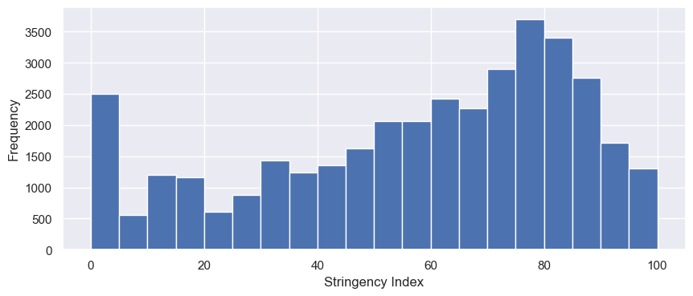

```python
bins = np.arange(0, 100+5, 5)

plt.hist(df['stringency_index'], bins=bins)

plt.xlabel('Stringency Index')
plt.ylabel('Frequency');
```

## Daily Cases Distribution per Continent

Back to Programmatic Assessment

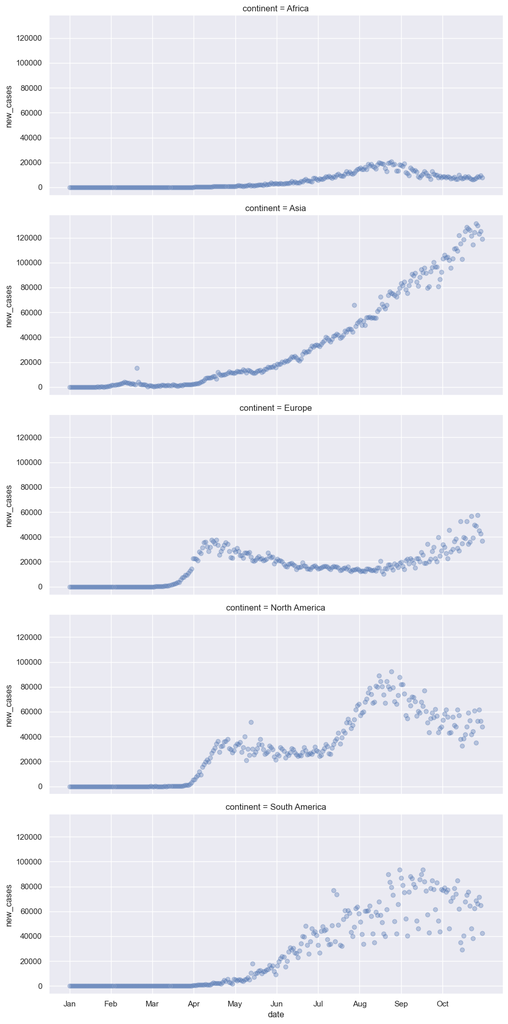

```python
# Subsetting the data
cont_cases = df[['continent', 'date', 'new_cases']].groupby(['continent', 'date']).sum().reset_index()

# Drop dates beforew (2019-12-31) and 'Oceania' records (different y scale)
cont_cases_no_o = cont_cases[(cont_cases['date'] > '2019-12-31') &
                             (cont_cases['continent'] != 'Oceania')].reset_index(drop=True)

# Creating function to plot each continent daily cases after mapping it to a FacetGrid object
def new_cases_scatter(x, y, **kwargs):
    plt.scatter(x, y, alpha=1/3)

    curr_xticks = plt.xticks()[0] # Getting current x ticks postions
    tick_width = len(curr_xticks) / 10 # Setting xticks width
    xticks = np.arange(np.array(curr_xticks).min(), np.array(curr_xticks).max(), tick_width) # Generating new xticks

    xticklabels = ['Jan', 'Feb', 'Mar', 'Apr', 'May', 'Jun', 'Jul', 'Aug', 'Sep', 'Oct'] # Setting xticks labels
    plt.xticks(ticks = xticks, labels = xticklabels);

# Creating FacetGrid Class
g = sb.FacetGrid(data = cont_cases_no_o, row = 'continent', height=4, aspect=2.5) # Create FacetGrid class
g.map(new_cases_scatter, 'date', 'new_cases');
```

## Daily Cases Distribution for Oceania

Back to Programmatic Assessment

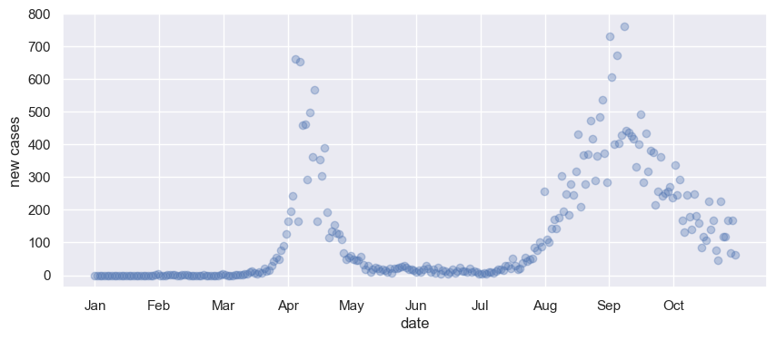

```python
# Scatter plot with 'Oceania' continent
cont_cases_o = cont_cases[cont_cases['continent'] == 'Oceania'].reset_index(drop=True)

# Creating scatter plot to visual new cases in Oceania
new_cases_scatter(cont_cases_o['date'], cont_cases_o['new_cases'])

plt.xlabel('date'), plt.ylabel('new cases');
```

# Assessment Docummentions

Let's seperate our docummentions by data issue types:

## Quality Issues

- The name of variable `location`.
- Variable `iso_code` name.
- Variable `tests_units` name.
- Variable `date` data type.
- Variables like `continent` and `tests_units` can be categorical data type.
- Values in variable `tests_units` (Uppercase).
- Missing values in `iso_code`.

## Tidiness Issues

- This dataset has multi-observational units, thus it can be divided into multi-tables:
  - **country:**
    - contains variables `iso_code`, `continent` and `location`.
  - **corona:**
    - contains `iso_code` and variables from `total_cases` to `stringency_index`.
  - **economy:**
    - contains variables `iso_code`, `gdp_per_capita` and `extreme_poverty`
  - **pop:**
    - contains variables `iso_code`, `population`, `population_density`, `median_age`, `aged_65_older` and `aged_70_older`.
  - **healthcare:**
    - contains `iso_code` and variables from `cardiovasc_death_rate` to `hospital_beds_per_thousand`.
  - **social:**
    - contains variables `iso_code`, `life_expectancy` and `human_development_index`.

Back to Assessing Data  
Advance to Data Cleaning Process

### So Far, So Good

> After we have `assessed` the dataset **manually** and **programmatically**, we're ready for the final step in Data Wrangling, **Cleaning Data**. And we are closer by one step our to reach **Our Goal**.
> - [X] Gathering
> - [X] Assessing
> - [ ] Cleaning
> - [ ] Storing
> - [ ] Analyzing
> - [ ] Visualizing
> - [ ] Reporting

> Back to Assessing Data

# Cleaning Data

[Cleaning Data](https://en.wikipedia.org/wiki/Data_cleansing) is the final step in Data Wrangling. It's the process of correcting (or removing) corrupt or inaccurate records from a record set, table, or database through replacing, modifying, or deleting the dirty.

### Data Cleaning Types:

Cleaning data can be done via two ways `manually` (inefficient, time consuming and error prone) and `programmatically` (for issues that occur more than one-time ).

### Data Cleaning Steps :

- `Define` is using verbs in order to call an action to fix the issue we observed.
- `Code` is doing the action.
- `Test` is assess whether it worked or not.

### Data Cleaning Process:

1. **Data Copying**
2. **Missing Values**
3. **Cleaning for Quality**
4. **Cleaning for Tidiness**

Back to Top  
Back to Assessment Docummention

## Data Copying

**Note:** Do not forget to copy each table before starting **Cleaning** phase, so, we can easily back to the original table of need.

Copying each dataframe using [DataFrame.copy](https://pandas.pydata.org/pandas-docs/stable/reference/api/pandas.DataFrame.copy.html)

Back to Cleaning Data

```python
df_copy = df.copy()
df_copy.head()
```

|  | iso_code | continent | location | date | total_cases | new_cases | new_cases_smoothed | total_deaths | new_deaths | new_deaths_smoothed | ... | gdp_per_capita | extreme_poverty | cardiovasc_death_rate | diabetes_prevalence | female_smokers | male_smokers | handwashing_facilities | hospital_beds_per_thousand | life_expectancy | human_development_index |
| --- | --- | --- | --- | --- | --- | --- | --- | --- | --- | --- | --- | --- | --- | --- | --- | --- | --- | --- | --- | --- | --- |
| 0 | ABW | North America | Aruba | 2020-03-13 | 2.0 | 2.0 | NaN | 0.0 | 0.0 | NaN | ... | 35973.781 | NaN | NaN | 11.62 | NaN | NaN | NaN | NaN | 76.29 | NaN |
| 1 | ABW | North America | Aruba | 2020-03-19 | NaN | NaN | 0.286 | NaN | NaN | 0.0 | ... | 35973.781 | NaN | NaN | 11.62 | NaN | NaN | NaN | NaN | 76.29 | NaN |
| 2 | ABW | North America | Aruba | 2020-03-20 | 4.0 | 2.0 | 0.286 | 0.0 | 0.0 | 0.0 | ... | 35973.781 | NaN | NaN | 11.62 | NaN | NaN | NaN | NaN | 76.29 | NaN |
| 3 | ABW | North America | Aruba | 2020-03-21 | NaN | NaN | 0.286 | NaN | NaN | 0.0 | ... | 35973.781 | NaN | NaN | 11.62 | NaN | NaN | NaN | NaN | 76.29 | NaN |
| 4 | ABW | North America | Aruba | 2020-03-22 | NaN | NaN | 0.286 | NaN | NaN | 0.0 | ... | 35973.781 | NaN | NaN | 11.62 | NaN | NaN | NaN | NaN | 76.29 | NaN |

5 rows × 41 columns

## Missing Values

As I discussed above the missing values in this dataset are due to its nature, thus, no further action is needed.

Back to Cleaning Data  
Back to Assessment Docummentions

## Cleaning for Quality

Now it's time to clean the dirty table!!

1. **Variables Location, Iso Code and Test Units Names**
2. **Variable Date Data Type**
3. **Variable Test Units Values**
4. **Variables Continent and Tests Unit Data Type**
5. **Iso Code Missing Values**

Back to Cleaning Data  
Back to Assessment Docummentions

### Variables Location, Iso Code and Test Units Names

Define Code Test

Back to Cleaning for Quality  
Back to Docummentions

#### Define

Change Variables names using `replace` function:

- **iso_code:** country_code
- **location:** country_name
- **tests_units:** test_units

Back

#### Code

Back

```python
# Creating a dictionary for the old and new names
new_names = {"iso_code"   : "country_code",
             "location"   : "country_name",
             "tests_units": "test_units"}

# Replcae old names with new names
df_copy.columns = pd.Series(df_copy.columns).replace(new_names).values
```

#### Test

Back

```python
# Check if the new names are in the column names
assert pd.Series(["country_code", "country_name", "test_units"]).isin(df_copy.columns).all()
```

### Variable Date Data Type

Define Code Test

Back to Cleaning for Quality  
Back to Docummentions

#### Define

Change data type for variable `date` from `object` to `datetime` using `to_datetime` method.

Back

#### Code

Back

```python
# Create category to set 'date' data type to datetime
def set_datetime_type(df):
    df['date'] = pd.to_datetime(df['date'])
set_datetime_type(df_copy)
```

#### Test

Back

```python
df_copy.date
```

```
0       2020-03-13
1       2020-03-19
2       2020-03-20
3       2020-03-21
4       2020-03-22
           ...
45202   2020-09-17
45203   2020-09-18
45204   2020-09-19
45205   2020-09-20
45206   2020-09-21
Name: date, Length: 45207, dtype: datetime64[ns]
```

### Variable Test Units Values

Define Code Test

Back to Cleaning for Quality  
Back to Docummentions

#### Define

Modify `test_units` values to be in title format instead of lowercase using `title` method and `lambda` function.

Back

#### Code

Back

```python
# Modifying 'Test Units' values
df_copy.test_units = df_copy.test_units.apply(lambda x: "People Tested (Incl. non-PCR)"
                                                              if x == "people tested (incl. non-PCR)"
                                                                      else(x.title() if type(x) != float
                                                                               else(x)))
```

#### Test

Back

```python
# Check 'test_units' values
df_copy.test_units.value_counts()
```

```
Tests Performed                  9655
People Tested                    4557
Samples Tested                   3731
Units Unclear                     441
People Tested (Incl. non-PCR)     191
Name: test_units, dtype: int64
```

### Variables Continent and Test Units Data Type

Define Code Test

Back to Cleaning for Quality  
Back to Docummentions

#### Define

Change data type for variables `continent` and `unit_types` from object to `categorical` data type using `astype` method.

Back

#### Code

Back

```python
# Creating two functions to replace datatypes for continent and test_units with new ones
def set_continent_dtype(df):
    continents_unique = pd.Series(df['continent'].unique()).dropna()
    # Creating new categorical type
    continent_category = pd.CategoricalDtype(continents_unique)
    # Replaceing old data type with new ones
    df['continent'] = df['continent'].astype(continent_category)

def set_test_units_dtype(df):
    test_units_unique = pd.Series(df['test_units'].unique()).dropna()
    unit_types_category = pd.CategoricalDtype(test_units_unique)
    df['test_units'] = df['test_units'].astype(unit_types_category)

# Changing the data types
set_continent_dtype(df_copy)
set_test_units_dtype(df_copy)
```

#### Test

Back

```python
df_copy[['continent', 'test_units']].dtypes
```

```
continent     category
test_units    category
dtype: object
```

### **Country Code Missing Values [Iso Code]**

Define Code Test

Back to Cleaning for Quality  
Back to Docummentions

#### Define

Replace missing values in `country_code` variable with `INT` as abbreviation to `International`.

Back

#### Code

Back

```python
# Replcae nulls in 'country_code' with 'INT'
df_copy['country_code'] = df_copy['country_code'].fillna('INT')
```

#### Test

Back

```python
# Making sure there are no nulls left in 'country_code'
assert df_copy['country_code'].isnull().any() == False
```

## Cleaning for Tidiness

Now, it's time for **Tidiness** issues.

Back to Cleaning Data  
Back to Assessment Docummentions

### Define

**Separate `df_copy` to the following tables:**

- **country:**
  - contains variables `country_code`, `continent` and `country_name`.
- **corona:**
  - contains `country_code` and variables from `date` to `stringency_index`.
- **economy:**
  - contains variables `country_code`, `gdp_per_capita` and `extreme_poverty`
- **pop:**
  - contains variables `country_code`, `population`, `population_density`, `median_age`, `aged_65_older` and `aged_70_older`.
- **healthcare:**
  - contains `country_code` and variables from `cardiovasc_death_rate` to `hospital_beds_per_thousand`.
- **social:**
  - contains variables `country_code`, `life_expectancy` and `human_development_index`.

Back

### Code

Back

```python
# Seperating each variable to its category
country_vars  = ['country_code', 'continent', 'country_name']
corona_vars     = ['country_code', 'date', 'total_cases', 'new_cases', 'new_cases_smoothed', 'total_deaths', 'new_deaths',
                   'new_deaths_smoothed', 'total_cases_per_million', 'new_cases_per_million', 'new_cases_smoothed_per_million',
                   'total_deaths_per_million', 'new_deaths_per_million', 'new_deaths_smoothed_per_million', 'new_tests',
                   'total_tests', 'total_tests_per_thousand', 'new_tests_per_thousand', 'new_tests_smoothed',
                   'new_tests_smoothed_per_thousand', 'tests_per_case', 'positive_rate', 'test_units', 'stringency_index']
economy_vars    = ['country_code', 'gdp_per_capita', 'extreme_poverty']
population_vars = ['country_code', 'population', 'population_density', 'median_age', 'aged_65_older', 'aged_70_older']
healthcare_vars = ['country_code', 'cardiovasc_death_rate', 'diabetes_prevalence', 'female_smokers',
                   'male_smokers', 'handwashing_facilities', 'hospital_beds_per_thousand',]
social_vars     = ['country_code', 'life_expectancy', 'human_development_index']

# Creating list for dataframe names
df_names = ['country', 'corona', 'economy', 'pop', 'healthcare', 'social']

# Creating list for dataframe variables
df_vars = [country_vars, corona_vars, economy_vars, population_vars, healthcare_vars, social_vars]

# Creating new dataframes with new variables
for df_name, df_var in zip(df_names, df_vars):
    vars()[df_name] = df_copy.copy()[df_var] # Using vars() to use string as variable

# Drop duplicated values after creating the new variables (country attributes)
dfs_non_corona = [country, corona, economy, pop, healthcare, social]
for df_before in dfs_non_corona:
    df_before.drop_duplicates(inplace = True)
    df_before.reset_index(inplace = True, drop = True) # Reset index and don't store the old index
```

### Test

Back

```python
# Checking duplicated values in dataframes
dfs_with_corona = [country, corona, economy, pop, healthcare, social]
for df_clean in dfs_with_corona:
    assert df_clean.duplicated(keep = False).any() == False

# Check if the new dataframes except 'corona' == 212 number of unique countries
dfs_non_corona = [country, economy, pop, healthcare, social]
for df_non_corona in dfs_non_corona:
    assert df_non_corona.shape[0] == 212
    assert 'country_code' in df_non_corona.columns.values

# Displaying a random sample of each dataframe
for df_clean in dfs_with_corona:
    display(df_clean.sample(4))
```

|  | country_code | continent | country_name |
| --- | --- | --- | --- |
| 53 | DNK | Europe | Denmark |
| 18 | BGD | Asia | Bangladesh |
| 89 | IDN | Asia | Indonesia |
| 128 | MLT | Europe | Malta |

|  | country_code | date | total_cases | new_cases | new_cases_smoothed | total_deaths | new_deaths | new_deaths_smoothed | total_cases_per_million | new_cases_per_million | ... | new_tests | total_tests | total_tests_per_thousand | new_tests_per_thousand | new_tests_smoothed | new_tests_smoothed_per_thousand | tests_per_case | positive_rate | test_units | stringency_index |
| --- | --- | --- | --- | --- | --- | --- | --- | --- | --- | --- | --- | --- | --- | --- | --- | --- | --- | --- | --- | --- | --- |
| 646 | AIA | 2020-04-04 | 3.0 | 0.0 | 0.143 | 0.0 | 0.0 | 0.000 | 199.973 | 0.000 | ... | NaN | NaN | NaN | NaN | NaN | NaN | NaN | NaN | NaN | 74.07 |
| 4399 | BHR | 2020-02-23 | 0.0 | 0.0 | 0.000 | 0.0 | 0.0 | 0.000 | 0.000 | 0.000 | ... | NaN | NaN | NaN | NaN | NaN | NaN | NaN | NaN | NaN | 19.44 |
| 30645 | NGA | 2020-09-12 | 56017.0 | 188.0 | 182.000 | 1076.0 | 1.0 | 3.571 | 271.743 | 0.912 | ... | 1904.0 | 438135.0 | 2.125 | 0.009 | 2962.0 | 0.014 | 16.275 | 0.061 | Samples Tested | NaN |
| 37488 | SSD | 2020-08-31 | 2519.0 | 0.0 | 2.857 | 47.0 | 0.0 | 0.000 | 225.037 | 0.000 | ... | NaN | NaN | NaN | NaN | NaN | NaN | NaN | NaN | NaN | 77.78 |

4 rows × 24 columns

|  | country_code | gdp_per_capita | extreme_poverty |
| --- | --- | --- | --- |
| 95 | ISL | 46482.958 | 0.2 |
| 27 | BRA | 14103.452 | 3.4 |
| 176 | SVK | 30155.152 | 0.7 |
| 114 | LIE | NaN | NaN |

|  | country_code | population | population_density | median_age | aged_65_older | aged_70_older |
| --- | --- | --- | --- | --- | --- | --- |
| 152 | PHL | 109581085.0 | 351.873 | 25.2 | 4.803 | 2.661 |
| 167 | SGP | 5850343.0 | 7915.731 | 42.4 | 12.922 | 7.049 |
| 24 | BLZ | 397621.0 | 16.426 | 25.0 | 3.853 | 2.279 |
| 38 | CMR | 26545864.0 | 50.885 | 18.8 | 3.165 | 1.919 |

|  | country_code | cardiovasc_death_rate | diabetes_prevalence | female_smokers | male_smokers | handwashing_facilities | hospital_beds_per_thousand |
| --- | --- | --- | --- | --- | --- | --- | --- |
| 12 | AZE | 559.812 | 7.11 | 0.3 | 42.5 | 83.241 | 4.70 |
| 197 | USA | 151.089 | 10.79 | 19.1 | 24.6 | NaN | 2.77 |
| 11 | AUT | 145.183 | 6.35 | 28.4 | 30.9 | NaN | 7.37 |
| 24 | BLZ | 176.957 | 17.11 | NaN | NaN | 90.083 | 1.30 |

|  | country_code | life_expectancy | human_development_index |
| --- | --- | --- | --- |
| 56 | ECU | 77.01 | 0.752 |
| 9 | ATG | 77.02 | 0.780 |
| 80 | GRL | 71.70 | NaN |
| 177 | SVN | 81.32 | 0.896 |

### So Far, So Good

> Now, we have complete wrangling the data set it's time to Store it. Let's cehck Our Goal.
> - [X] Gathering
> - [X] Assessing
> - [X] Cleaning
> - [ ] Storing
> - [ ] Analyzing
> - [ ] Visualizing
> - [ ] Reporting

> Back to Cleaning Data

# Data Storing

After **Gathering**, **Assessing** and **Cleaning** our data, we are ready to store it.

In this project we will store our data in `CSV` files.

Back to Top

```python
import os

# dfs and df names
dfs_with_corona = [country, corona, economy, pop, healthcare, social]
df_names = ['country', 'corona', 'economy', 'pop', 'healthcare', 'social']

# Removing old stored dataframes to start fresh
for df_name in df_names:
    df_path = 'data/{}.csv'.format(df_name)
    if os.path.exists(df_path):
        os.remove(df_path)

# Save each dataframe to CSV file
for df_clean, df_name in zip(dfs_with_corona, df_names):
    df_clean.to_csv('data/{}_clean.csv'.format(df_name), index=False)
```

### So Far, So Good

> Now, Our data are stored in these tables and ready to be used in next **Analyzing and Visualizing** notebook.
> - [X] Gathering
> - [X] Assessing
> - [X] Cleaning
> - [x] Storing
> - [ ] Analyzing
> - [ ] Visualizing
> - [ ] Reporting

> Back to Data Storing